# Part 2: Basic Inferential Data Analysis Instructions

Gyeong-Geun LEE

# setup

```r
library(tidyverse)   # load basic tools

df <- ToothGrowth    # load data
df
```

| len | supp | dose |
| --- | --- | --- |
| 4.2 | VC | 0.5 |
| 11.5 | VC | 0.5 |
| 7.3 | VC | 0.5 |
| 5.8 | VC | 0.5 |
| 6.4 | VC | 0.5 |
| 10.0 | VC | 0.5 |
| 11.2 | VC | 0.5 |
| 11.2 | VC | 0.5 |
| 5.2 | VC | 0.5 |
| 7.0 | VC | 0.5 |

[output cut: 50 more lines]

# EDA

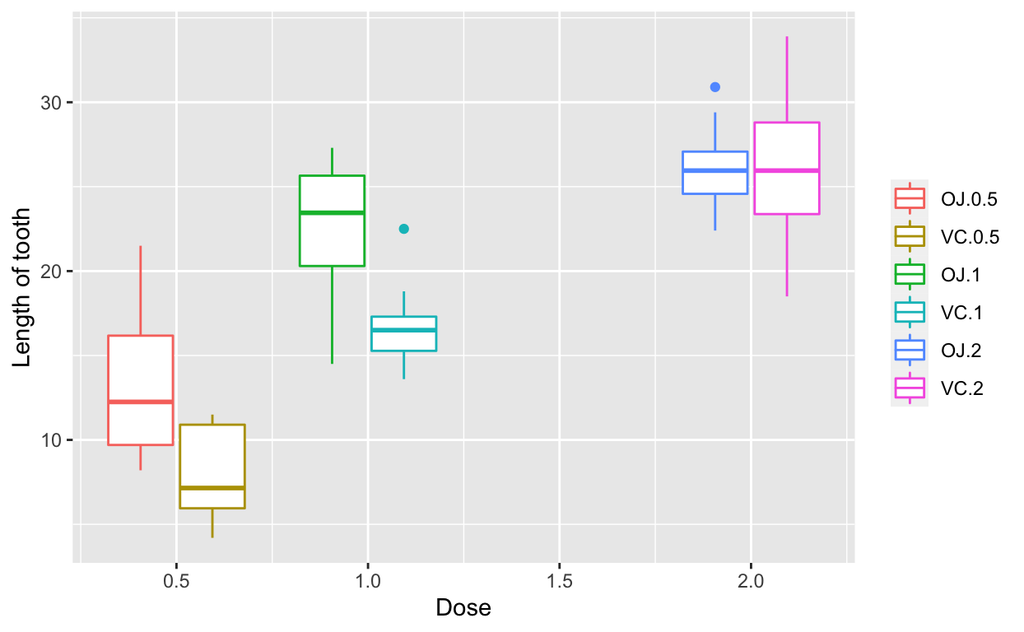

```r
df %>%
  ggplot(aes(dose, len)) +
  geom_boxplot(aes(color = interaction(supp, dose))) +
  labs(x = "Dose", y = "Length of tooth") +
  theme(legend.title = element_blank())
```

# Basic summary of the data

Five numers of data was obtained, and sd was also calculated.

```r
df %>%
  group_by(supp, dose) %>%
  summarize(
    mean = mean(len),
    sd = sd(len),
    min = min(len),
    Q1 = quantile(len, 0.25),
    median = median(len),
    Q3 = quantile(len, 0.75),
    max = max(len),
    .groups = "drop"
  )
```

| supp | dose | mean | sd | min | Q1 | median | Q3 | max |
| --- | --- | --- | --- | --- | --- | --- | --- | --- |
| OJ | 0.5 | 13.23 | 4.459709 | 8.2 | 9.700 | 12.25 | 16.175 | 21.5 |
| OJ | 1.0 | 22.70 | 3.910953 | 14.5 | 20.300 | 23.45 | 25.650 | 27.3 |
| OJ | 2.0 | 26.06 | 2.655058 | 22.4 | 24.575 | 25.95 | 27.075 | 30.9 |
| VC | 0.5 | 7.98 | 2.746634 | 4.2 | 5.950 | 7.15 | 10.900 | 11.5 |
| VC | 1.0 | 16.77 | 2.515309 | 13.6 | 15.275 | 16.50 | 17.300 | 22.5 |
| VC | 2.0 | 26.14 | 4.797731 | 18.5 | 23.375 | 25.95 | 28.800 | 33.9 |

# Hypothesis tests

all conditions are splited.

```r
# all conditions are splited.
vc0.5 <- df %>% filter(supp == "VC", dose == 0.5) %>% pull(len)
vc1.0 <- df %>% filter(supp == "VC", dose == 1.0) %>% pull(len)
vc2.0 <- df %>% filter(supp == "VC", dose == 2.0) %>% pull(len)
oj0.5 <- df %>% filter(supp == "OJ", dose == 0.5) %>% pull(len)
oj1.0 <- df %>% filter(supp == "OJ", dose == 1.0) %>% pull(len)
oj2.0 <- df %>% filter(supp == "OJ", dose == 2.0) %>% pull(len)
```

## Comparision between supplement at the same dose

### dose = 0.5

The p-value is 0.005304, and null hypothesis was rejected.

```r
t.test(vc0.5, oj0.5, alternative = "two.sided", var.equal = TRUE)
```

```
    Two Sample t-test

data:  vc0.5 and oj0.5
t = -3.1697, df = 18, p-value = 0.005304
alternative hypothesis: true difference in means is not equal to 0
95 percent confidence interval:
 -8.729738 -1.770262
sample estimates:
mean of x mean of y
     7.98     13.23
```

### dose = 1.0

The p-value is 0.0007807, and null hypothesis is rejected.

```r
t.test(vc1.0, oj1.0, alternative = "two.sided", var.equal = TRUE)
```

```
    Two Sample t-test

data:  vc1.0 and oj1.0
t = -4.0328, df = 18, p-value = 0.0007807
alternative hypothesis: true difference in means is not equal to 0
95 percent confidence interval:
 -9.019308 -2.840692
sample estimates:
mean of x mean of y
    16.77     22.70
```

### dose = 2.0

The p-value is 0.9637, and null hypothesis can not be rejected.

```r
t.test(vc2.0, oj2.0, alternative = "two.sided", var.equal = TRUE)
```

```
    Two Sample t-test

data:  vc2.0 and oj2.0
t = 0.046136, df = 18, p-value = 0.9637
alternative hypothesis: true difference in means is not equal to 0
95 percent confidence interval:
 -3.562999  3.722999
sample estimates:
mean of x mean of y
    26.14     26.06
```

## Comparision between dose at the same supplement

### Vitamin C

Comparing dose 0.5 to 1.0, the p-value is 6.492e-07, and null hypothesis is rejected.

```r
t.test(vc0.5, vc1.0, alternative = "two.sided", var.equal = TRUE)
```

```
    Two Sample t-test

data:  vc0.5 and vc1.0
t = -7.4634, df = 18, p-value = 6.492e-07
alternative hypothesis: true difference in means is not equal to 0
95 percent confidence interval:
 -11.264346  -6.315654
sample estimates:
mean of x mean of y
     7.98     16.77
```

Comparing dose 1.0 to 2.0, the p-value is 3.398e-05, and null hypothesis is rejected.

```r
t.test(vc1.0, vc2.0, alternative = "two.sided", var.equal = TRUE)
```

```
    Two Sample t-test

data:  vc1.0 and vc2.0
t = -5.4698, df = 18, p-value = 3.398e-05
alternative hypothesis: true difference in means is not equal to 0
95 percent confidence interval:
 -12.96896  -5.77104
sample estimates:
mean of x mean of y
    16.77     26.14
```

### Orange juice

Comparing dose 0.5 to 1.0, the p-value is 8.358e-05, and null hypothesis is rejected.

```r
t.test(oj0.5, oj1.0, alternative = "two.sided", var.equal = TRUE)
```

```
    Two Sample t-test

data:  oj0.5 and oj1.0
t = -5.0486, df = 18, p-value = 8.358e-05
alternative hypothesis: true difference in means is not equal to 0
95 percent confidence interval:
 -13.410814  -5.529186
sample estimates:
mean of x mean of y
    13.23     22.70
```

Comparing dose 1.0 to 2.0, the p-value is 0.03736, and null hypothesis is rejected.

```r
t.test(oj1.0, oj2.0, alternative = "two.sided", var.equal = TRUE)
```

```
    Two Sample t-test

data:  oj1.0 and oj2.0
t = -2.2478, df = 18, p-value = 0.03736
alternative hypothesis: true difference in means is not equal to 0
95 percent confidence interval:
 -6.5005017 -0.2194983
sample estimates:
mean of x mean of y
    22.70     26.06
```

# Conclusion

All data was assumed to be follow t-distribution.